# infer 02 - Numerical inference

Daniel Jiménez

12/19/2019

```r
library(infer);
library(tidyverse);
library(emo);
theme_set(theme_classic())
```

# Some approach

## Bootstrapping techniques

- First : Bootstrap is a powerful method for statistical inference (with based on computational algorithms) that allows assigning measures of accuracy to sample estimates.
- Second : It`s widely applied in other statistical inference such as
  - Confidence interval
  - Regression Models
  - Machine Learning

Some conceptions : i) Assume the data is representative, ii) use random sample with replacement to make inferences about the unknown population (statistical universe). iii) Calculate or compute robust statistics tools - mean, variance , error , median , etc through on samples. iv) repeat steps many times to creat bootstrap distribution

In this example , with iris `emo::ji("face")` I generate bootstrap distribution for median.

```r
sepal_med_ci<-iris%>%
  specify(response = Sepal.Length )%>% # Specify the variable of interes
  generate(reps = 100, type="bootstrap")%>%
  calculate(stat = "median")

sepal_med_ci%>%
  head()%>%
  knitr::kable(format = 'markdown', caption = 'Bootstrap Distribution for media')
```

| replicate | stat |
| --- | --- |
| 1 | 5.75 |
| 2 | 5.80 |
| 3 | 5.70 |
| 4 | 5.70 |
| 5 | 5.75 |
| 6 | 5.70 |

Now , is necessary generate histogram plot about this

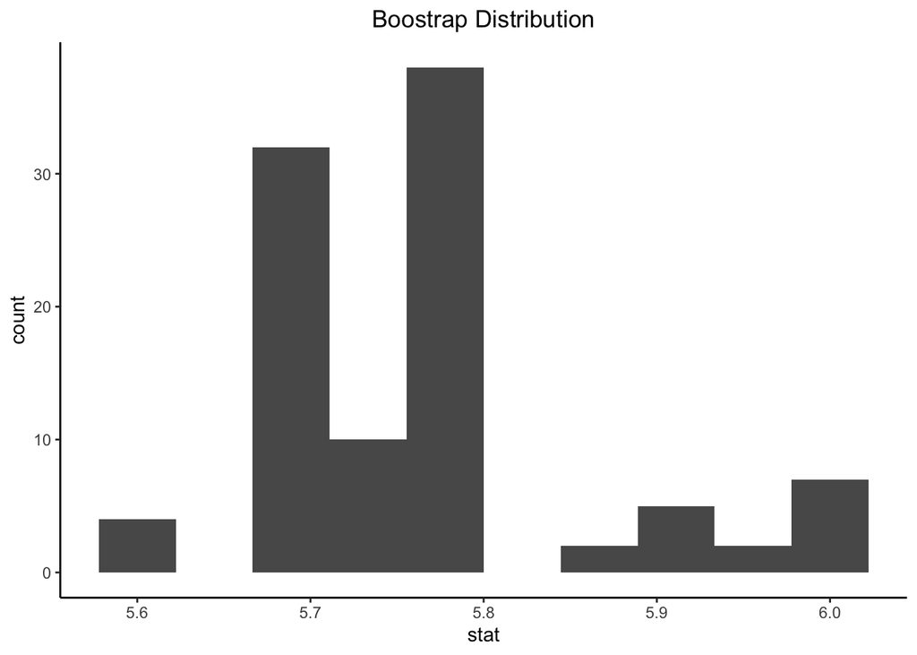

```r
sepal_med_ci%>%
  ggplot(aes(stat))+
  geom_histogram(bins = 10)+
  labs(title = 'Boostrap Distribution')+
  theme(plot.title = element_text(hjust = 0.5))
```